# whole_brain_mvpa_intro slides

2019 KHBM Summer School, OHBM Korea Chapter Program

Mutivoxel-pattern analysis (MVPA) for whole brain

August 17, 2019

Brain Signal Processing Lab (BSPL)

Department of Brain and Cognitive Engineering

Korea University, Republic of Korea

Jong-Hwan Lee, Juhyeon Lee, Hyun-Chul Kim

## Contents

### (1) Introduction of whole brain multivoxel pattern analysis (MVPA)

### (2) Simple neural networks based computational models for MVPA

### (3) Optimizing the neural networks by reducing the degree of overfitting using L1/L2-norm optimization of model weights

# Intro: Whole brain multivoxel pattern analysis (MVPA)

## Schematics of whole brain MVPA

[figure not shown]

Computational model: Logistic regression, support vector machine, decision trees have been widely used.

# Intro: Deep neural networks based computational model

## Deep neural networks including a Convolutional neural network (CNN) has been outperformed traditionally popular machine learning models.

[figure not shown]

- acheived apprximately 16% top-5 error rate from the ILSVRC-2012 competition (runner-up: 26%; http://image-net.org/challenges/LSVRC/2012/results.html#t3)

# Intro: Deep neural network (DNN)

## DNN is a neural network based computational model with multiple non-linear transformation layers.

model parameters (i.e., weight parameters) can be determined based on iterative learning to minimize a cost function (e.g., an error between true target values and estimaetd target values).

[figure not shown]

# Intro: Whole brain MVPA using DNN

## In this tutorial session, we are going to describe how we can use the fully-connected feedforward DNN as a computational model.

[figure not shown]

# Intro: Whole brain MVPA using DNN

## For a simplicity, let's break down the whole brain MVPA into multiple "one input voxel" to "one output concept" setting.

[figure not shown]

*Note: of course, the model will undergo more complex interaction across layers when multiple input and multiple output nodes are consider.

# Intro: "one input" and "one output" mapping

## Further simplifying the model having only one-hidden layer

### Now, we have "one input" and "one output" mapping and there is only "one hidden layer" for non-linear transformation.

[figure not shown]

# Simulation: "One input" to "One output" mapping

## Let's consider the following simulated problem of "one input" and "one output" mapping problem.

[figure not shown]

- Numbers of training data = 80, validation data = 20, and test data = 100
- BTW, the above examples were generated from the following mathematical model: $$ y = 20(x - 1)(x-2)(x-3) $$

*The specific code to generate the data are below.

```python
# import necessary libraries and modules
import numpy as np
import pandas as pd
import matplotlib.pyplot as plt
from sklearn.model_selection import train_test_split
import tensorflow as tf
import scipy.io as sio
```

```python
def quadratic_fn(x):
    y = -2*x* x + 4*x + 1
    return y

def linear_fn(x):
    y = 2 * x + 0.5
    return y

def cubic_fn(x):
    #coeff = np.random.randn(4)
    #y = np.empty(0)
    #for idx in range(4):
    #    y += coeff[idx]*np.power(x, idx)
    y = 20 * np.multiply(np.multiply(x - 1, x - 2), x-3)
    return y

    #y = coeff[0]*np.pow(x, 3) + coeff[1]*
```

```python
#####################################
## generating training/validation set
#####################################
#x = 2 * np.random.rand(10)  # uniformly between 0 and 2
x = 4 * np.random.rand(10)  # uniformly between 0 and 2
#y = quadratic_fn(x) # y is a quadratic function of x
y = cubic_fn(x) # y is a cubic function of x

data_x, data_y = np.empty(0), np.empty(0)
for xval, yval in zip(x, y):
    data_x = np.append(data_x, np.random.randn(10)*0.01 + xval)
    #data_y = np.append(data_y, np.random.randn(10)*1.0 + yval)
data_y = cubic_fn(data_x) + np.random.randn(data_x.shape[0])*1.0
data_x = data_x[:, np.newaxis]

#plt.plot(data_x, data_y, 'o')
#plt.show()

x_tr, x_val, y_tr, y_val = train_test_split(data_x, data_y, test_size=0.2)

######################
## generating test set
######################
x_ts = 4 * np.random.rand(100)  # uniformly between 0 and 2
x_ts = x_ts[:, np.newaxis]
#y_ts = quadratic_fn(x_ts) # y is a quadratic function of x
y_ts = cubic_fn(x_ts) # y is a quadratic function of x
```

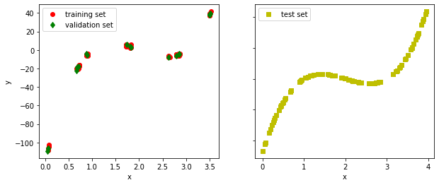

```python
# Load an existing dataset
matdata = sio.loadmat('sim_data.mat')
x_tr, y_tr = matdata['x_tr'], matdata['y_tr'].flatten()
x_val, y_val = matdata['x_val'], matdata['y_val'].flatten()
x_ts, y_ts = matdata['x_ts'], matdata['y_ts'].flatten()

# visualize the data
f, axs = plt.subplots(1, 2, figsize=(10,4))
axs[0].plot(x_tr, y_tr, 'ro', label='training set')
axs[0].plot(x_val, y_val, 'gd', label='validation set')
axs[0].set(xlabel='x', ylabel='y')
axs[0].legend()
axs[1].plot(x_ts, y_ts, 'ys', label='test set')
axs[1].set(xlabel='x', ylabel='y')
axs[1].legend()
for ax in axs.flat:
    ax.label_outer()
plt.show()
```

# Q: How we can solve this problem?

## Let's start with a very simple linear model as follows:

[figure not shown]

$$ y = w x + b,$$

where $x$ and $y$ are the input and output data, $w$ and $b$ are the weight and bias parameters.

The trainable parameters, $w$ and $b$ can be obtained by minimizing a cost function (J) such as the mean-squared error (MSE) between an actual target ($y$) and a predicted target ($\hat{y}$) using training/validation data: $$ J = \sum_i |y_i - \hat{y}_i|^2 $$

*The code snippet to define the linear model, to train the model, and to predict the model is shown below:

```python
# linear regression model using TF
class TFlinear(object):
    def __init__(self, x_dim, learning_rate = 0.01):
        self.x_dim = x_dim
        self.learning_rate = learning_rate
        self.g = tf.Graph()
        # build the model
        with self.g.as_default():
            self.build()
            self.init_op = tf.global_variables_initializer()

    def build(self):
        self.X = tf.placeholder(dtype=tf.float32,
                    shape=(None, self.x_dim), name='x_input')
        self.y = tf.placeholder(dtype=tf.float32,
                    shape=(None), name='y_output')
        print(self.X)
        print(self.y)
        w = tf.Variable(tf.truncated_normal(shape=(1,1), stddev=0.1), name='weight')
        b = tf.Variable(tf.ones(shape=(1))*0.1, name='bias')
        print(w)
        print(b)

        self.z_net = tf.squeeze(self.X*w + b, name='z_net')
        print(self.z_net)

        self.y_hat = self.z_net
        sqr_err = tf.square(self.y - self.y_hat, name='sqr_err')
        print(sqr_err)

        self.mse_cost = tf.reduce_mean(sqr_err, name='mse_cost')
        print(self.mse_cost)

        self.cost = self.mse_cost

        optimizer = tf.train.GradientDescentOptimizer(
            learning_rate = self.learning_rate, name='GradientDescent')

        self.train_op = optimizer.minimize(self.cost, name='train_op')
```

```python
# This function is to train the linear model
def train_model(sess, model, X_train, y_train, n_epochs=100):
    sess.run(model.init_op)
    tr_cost = []
    for i in range(n_epochs):
        # This is for linear model for now
        _, cost = sess.run([model.train_op, model.cost], feed_dict={model.X: X_train, model.y: y_train})
        tr_cost.append(cost),

        if not i % 100:
            print('Epoch {:3d}: {:.4f}'.format(i, cost))
    return tr_cost # for one layer (linear) model

# function to return the predicted output
def predict_model(sess, model, X_test, y_test):
    y_pred = sess.run(model.y_hat, feed_dict={model.X: X_test})
    mse_err = np.mean(np.square(y_test - y_pred))
    return y_pred, mse_err
```

# Simple linear model

## This linear model has been successfully trained, however, (as expected) the predicted response showed a lack of capacity to model the non-linear relationship between the input and output data.

*code below

```
Tensor("x_input:0", shape=(?, 1), dtype=float32)
Tensor("y_output:0", dtype=float32)
<tf.Variable 'weight:0' shape=(1, 1) dtype=float32_ref>
<tf.Variable 'bias:0' shape=(1,) dtype=float32_ref>
Tensor("z_net:0", dtype=float32)
Tensor("sqr_err:0", dtype=float32)
Tensor("mse_cost:0", shape=(), dtype=float32)
Epoch   0: 1172.1433
Epoch 100: 947.6387
Epoch 200: 804.0765
Epoch 300: 711.6978
Epoch 400: 652.2545
Epoch 500: 614.0041
Epoch 600: 589.3911
Epoch 700: 573.5531
Epoch 800: 563.3618
Epoch 900: 556.8040
Epoch 1000: 552.5841
Epoch 1100: 549.8688
Epoch 1200: 548.1215
Epoch 1300: 546.9972
Epoch 1400: 546.2737
Epoch 1500: 545.8082
Epoch 1600: 545.5087
Epoch 1700: 545.3159
Epoch 1800: 545.1918
Epoch 1900: 545.1121
Epoch 2000: 545.0607
Epoch 2100: 545.0276
Epoch 2200: 545.0063
Epoch 2300: 544.9927
Epoch 2400: 544.9839
Epoch 2500: 544.9782
Epoch 2600: 544.9745
Epoch 2700: 544.9722
Epoch 2800: 544.9707
Epoch 2900: 544.9697
Epoch 3000: 544.9691
Epoch 3100: 544.9687
Epoch 3200: 544.9684
Epoch 3300: 544.9683
Epoch 3400: 544.9681
Epoch 3500: 544.9681
Epoch 3600: 544.9681
Epoch 3700: 544.9681
Epoch 3800: 544.9680
Epoch 3900: 544.9680
Epoch 4000: 544.9680
Epoch 4100: 544.9680
Epoch 4200: 544.9680
Epoch 4300: 544.9680
Epoch 4400: 544.9680
Epoch 4500: 544.9680
Epoch 4600: 544.9680
Epoch 4700: 544.9680
Epoch 4800: 544.9680
Epoch 4900: 544.9680
```

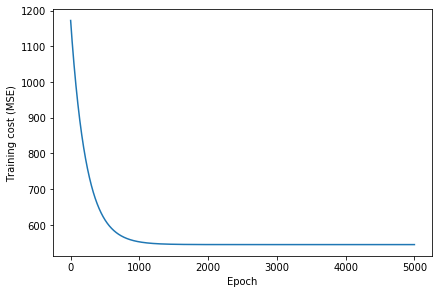

```
training mse: 544.9680, testing mse: 809.6813
```

```python
# For one-layer: train and test the model
# define the model
lrmodel = TFlinear(x_dim=x_tr.shape[1], learning_rate=0.005)
sess = tf.Session(graph=lrmodel.g)
# train the model
tr_costs = train_model(sess, lrmodel, x_tr, y_tr, n_epochs=5000)

# visualize the training costs from linear model
plt.plot(range(1,len(tr_costs)+1), tr_costs)
plt.tight_layout()
plt.xlabel('Epoch')
plt.ylabel('Training cost (MSE)')
plt.show()

# test the trained model
model = lrmodel
y_tr_pred, mse_err_tr = predict_model(sess, model, x_tr, y_tr)
y_ts_pred, mse_err_ts = predict_model(sess, model, x_ts, y_ts)

print("training mse: {:.4f}, testing mse: {:.4f}".format(mse_err_tr, mse_err_ts))
```

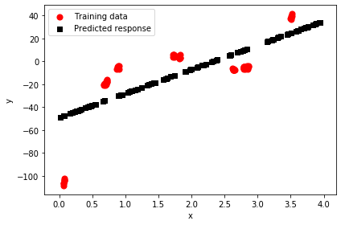

```python
# plot the training data and fitted response for the training data
plt.scatter(x_tr, y_tr, color='red', marker='o', s=50, label='Training data')
plt.scatter(x_ts, y_ts_pred, color='black', marker='s',
        label='Predicted response')
plt.xlabel('x')
plt.ylabel('y')
plt.legend()
plt.tight_layout()
plt.show()
```

# Non-linear neural network (NN) model

## Now, let's consider a NN model with one hidden layer

[figure not shown]

In this model, the hidden node representation is as follows:

$$ z_i = w_{1,i} x + b_{1,i}, \hspace{1cm} h_i = \varphi (z_i), \hspace{1cm} y = \sum_{j=1}^{n} w_{2,j} h_j + b_2, $$

where $\varphi(\cdot)$ is a non-linear function (e.g., sigmoid, tanh, and ReLU).

*Code snippet is below.

```python
# two-layer neural network implementation using TF
class TF2layer(object):
    def __init__(self, x_dim, h_dim, l1param=0.001, l2param=0.00001, learning_rate = 0.01):
        self.x_dim = x_dim
        self.h_dim = h_dim
        self.l1param = l1param # L1-norm parameter
        self.l2param = l2param # L2-norm parameter
        self.learning_rate = learning_rate
        self.g = tf.Graph()
        # build the model
        with self.g.as_default():
            self.build()
            self.init_op = tf.global_variables_initializer()
```

```python
    def build(self):
        self.X = tf.placeholder(dtype=tf.float32,
                    shape=(None, self.x_dim), name='x_input')
        self.y = tf.placeholder(dtype=tf.float32,
                    shape=(None), name='y_output')
        print(self.X)
        print(self.y)
        self.w1 = tf.Variable(tf.truncated_normal(shape=(self.x_dim, self.h_dim), stddev=0.1), name='weight1')
        self.b1 = tf.Variable(tf.ones(shape=(self.h_dim))*0.1, name='bias1')
        print(self.w1)
        print(self.b1)

        self.z_net = tf.squeeze(tf.matmul(self.X, self.w1) + self.b1, name='z_net')
        print(self.z_net)

        #self.h = self.z_net
        self.h = tf.tanh(self.z_net)

        self.w2 = tf.Variable(tf.truncated_normal(shape=(self.h_dim, 1), stddev=0.1), name='weight2')
        self.b2 = tf.Variable(tf.ones(shape=(1))*0.1, name='bias2')
        print(self.w2)
        print(self.b2)

        self.y_hat = tf.squeeze(tf.matmul(self.h, self.w2) + self.b2, name='y_hat')
        print(self.y_hat)

        sqr_err = tf.square(self.y - self.y_hat, name='sqr_err')
        print(sqr_err)

        self.l1norm = tf.multiply(self.l1param, tf.add(tf.reduce_sum(tf.abs(self.w1)), tf.reduce_sum(tf.abs(self.w2))))
        self.l2norm = tf.multiply(self.l2param, tf.add(tf.reduce_sum(tf.pow(self.w1, 2)), tf.reduce_sum(tf.pow(self.w2, 2))))

        self.mse_cost = tf.reduce_mean(sqr_err, name='mse_cost')
        print(self.mse_cost)

        self.cost = self.mse_cost

        optimizer = tf.train.GradientDescentOptimizer(
            learning_rate = self.learning_rate, name='GradientDescent')

        self.train_op = optimizer.minimize(self.mse_cost, name='train_op')
```

# One hidden layer neural net model

## Now, let's try the model for various number of hidden nodes/units.

### First, n = 2 (i.e., network with two hidden nodes)

[figure not shown]

- Cost function converges well as the learning goes.
- BTW, 'l1norm' and 'l2norm' is the L1-norm and L2-norm of the model weights.

*code snippet is below.

```python
# This function is to train the two-layer model
def train_model(sess, model, X_train, y_train, n_epochs=100):
    sess.run(model.init_op)
    tr_cost, tr_mse_cost, tr_l1norm, tr_l2norm, = [], [], [], []
    for i in range(n_epochs):
        # The below is for two-layer model
        _, mse_cost, l1norm, l2norm, cost = sess.run([model.train_op, model.mse_cost, model.l1norm
                    , model.l2norm, model.cost], feed_dict={model.X: X_train, model.y: y_train})
        tr_cost.append(cost), tr_mse_cost.append(mse_cost), tr_l1norm.append(l1norm), tr_l2norm.append(l2norm)

        if not i % 100:
            print('Epoch {:3d}: {:.4f}'.format(i, cost))
    return tr_cost, tr_mse_cost, tr_l1norm, tr_l2norm # for two layer model

# function to return the predicted output
def predict_model(sess, model, X_test, y_test):
    y_pred = sess.run(model.y_hat, feed_dict={model.X: X_test})
    mse_err = np.mean(np.square(y_test - y_pred))
    return y_pred, mse_err
```

[output not shown]

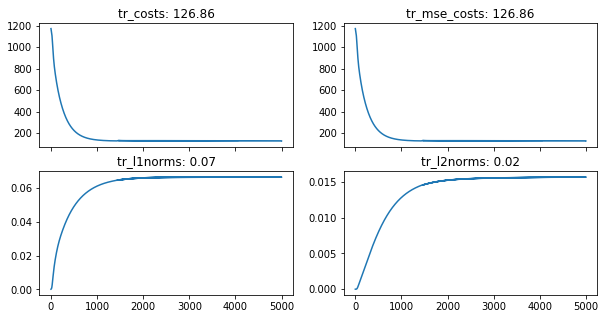

```python
# For two-layer without regularization: train and test the model
# define the model
twoLmodel = TF2layer(x_dim=x_tr.shape[1], h_dim=2, learning_rate=0.005) # for tanh
##twoLmodel = TF2layer(x_dim=x_tr.shape[1], h_dim=100, learning_rate=0.001) # for linear
## h_dim: 2 (underfitting; less capacity net), 10 (slightly underfitting),
##   100 (right model), 1000 (underfitting; too much capacity given net capacity)
## 5000 ()
sess = tf.Session(graph=twoLmodel.g)
# train the model
tr_costs, tr_mse_costs, tr_l1norms, tr_l2norms = train_model(sess, twoLmodel, x_tr, y_tr, n_epochs=5000)

# visualize the cost, mse_cost, l1norm, and l2norm
f, axs = plt.subplots(2, 2, sharex=True, figsize=(10, 5))
axs[0,0].plot(tr_costs)
axs[0,0].set_title('tr_costs: {:.2f}'.format(tr_costs[-1]))
axs[0,1].plot(tr_mse_costs)
axs[0,1].set_title('tr_mse_costs: {:.2f}'.format(tr_mse_costs[-1]))
axs[1,0].plot(tr_l1norms)
axs[1,0].set_title('tr_l1norms: {:.2f}'.format(tr_l1norms[-1]))
axs[1,1].plot(tr_l2norms)
axs[1,1].set_title('tr_l2norms: {:.2f}'.format(tr_l2norms[-1]))
plt.show()
```

# One hidden layer neural net model (2 hidden nodes)

## The following predicted data shows that the model is underfitting the training data.

Thus, the model is less capable of learning the concept in the training data.

[figure not shown]

*code is below

```python
# test the trained model
model = twoLmodel
y_tr_pred, mse_err_tr = predict_model(sess, model, x_tr, y_tr)
y_ts_pred, mse_err_ts = predict_model(sess, model, x_ts, y_ts)

print("training mse: {:.4f}, testing mse: {:.4f}".format(mse_err_tr, mse_err_ts))
```

[output not shown]

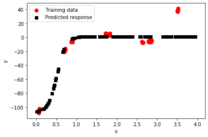

```python
# plot the training data and fitted response for the training data
plt.scatter(x_tr, y_tr, color='red', marker='o', s=50, label='Training data')
plt.scatter(x_ts, y_ts_pred, color='black', marker='s',
        label='Predicted response')
plt.xlabel('x')
plt.ylabel('y')
plt.legend()
plt.tight_layout()
plt.show()
```

# One hidden layer neural net model (cont'd)

## Now, n = 10 (i.e., 10 hidden nodes network)

The model fits much better than the one with n = 2.

# One hidden layer neural net model (cont'd)

## And, now, n = 100

The model fits better than the one with n = 10 and fits really well to the training/test data.

# One hidden layer neural net model (cont'd)

## And, n = 1,000

The model seems slightly overfitting to some training data.  
Test performance is degraded as compared to the one with n = 100.

# One hidden layer neural net model (cont'd)

## And, n = 5,000

Slightly more overfitting

# One hidden layer neural net model (cont'd)

## And, n = 10,000!

More overfitting to some training data?  
Test performance was even more degraded.

## As a summary (for now):

### 1. As the number of hidden nodes increased too much, the model seemed significantly overfitted to some training samples.

### 2. Thus, the generalization performance was substantially compromised.

### 3. We can also expect this potential overfitting issue from whole brain MVPA

i.e., number of input voxels is often greater than 50,000 and thus, number of hidden nodes need to be increased.  
On the other hand, the number of training samples are limited.

# Solution: let's regularize the model weights

## Goal is to penalize the model weights and in turn to reduce the model complexity.

[figure not shown]

$$ J = \alpha \sum_i |y_i - \hat{y}_i|^2 + \beta \sum_j |w_{1,j}| + \gamma \sum_k || w_{2,k} ||^2, $$

where $\alpha$, $\beta$, and $\gamma$ are the learning rate for the sum of squarred error, L1-norm, and L2-norm of weights, respectively.

# With regularization of weights, one hidden layer neural net model

## Number of hidden nodes = 5,000

### $\beta = 1.0$ and $\gamma = 1.0$

*code below

```python
# two-layer neural network with L1/L2-regularization implementation using TF
class TF2layer_l1l2(object):
    def __init__(self, x_dim, h_dim, alpha_param=1.0, l1param=0.001, l2param=0.00001, learning_rate = 0.01):
        self.x_dim = x_dim # number of input nodes
        self.h_dim = h_dim # number of hidden nodes
        self.alpha_param = alpha_param # ratio of mse in the cost
        self.l1param = l1param # L1-norm parameter
        self.l2param = l2param # L2-norm parameter
        self.learning_rate = learning_rate # learning rate for optimizer
        self.g = tf.Graph()
        # build the model
        with self.g.as_default():
            self.build()
            self.init_op = tf.global_variables_initializer()

    def build(self):
        self.X = tf.placeholder(dtype=tf.float32,
                    shape=(None, self.x_dim), name='x_input')
        self.y = tf.placeholder(dtype=tf.float32,
                    shape=(None), name='y_output')
        print(self.X)
        print(self.y)
        self.w1 = tf.Variable(tf.truncated_normal(shape=(self.x_dim, self.h_dim), stddev=0.1), name='weight1')
        self.b1 = tf.Variable(tf.ones(shape=(self.h_dim))*0.1, name='bias1')
        print(self.w1)
        print(self.b1)

        self.z_net = tf.squeeze(tf.matmul(self.X, self.w1) + self.b1, name='z_net')
        print(self.z_net)

        #self.h = self.z_net
        self.h = tf.tanh(self.z_net)

        self.w2 = tf.Variable(tf.truncated_normal(shape=(self.h_dim, 1), stddev=0.1), name='weight2')
        self.b2 = tf.Variable(tf.ones(shape=(1))*0.1, name='bias2')
        print(self.w2)
        print(self.b2)

        self.y_hat = tf.squeeze(tf.matmul(self.h, self.w2) + self.b2, name='y_hat')
        print(self.y_hat)

        sqr_err = tf.square(self.y - self.y_hat, name='sqr_err')
        print(sqr_err)

        self.mse_cost = tf.reduce_mean(sqr_err, name='mse_cost')
        print(self.mse_cost)
```

```python
        self.l1norm = tf.add(tf.reduce_sum(tf.abs(self.w1)), tf.reduce_sum(tf.abs(self.w2)))
        self.l2norm = tf.add(tf.reduce_sum(tf.pow(self.w1, 2)), tf.reduce_sum(tf.pow(self.w2, 2)))

        # L1- and L2-norm regularization (i.e., elastic net)
        self.cost = tf.multiply(self.alpha_param, self.mse_cost) + \
                        tf.multiply(self.l1param, self.l1norm) + \
                            tf.multiply(self.l2param, self.l2norm)
        #
        # L1-norm regularization (i.e., LASSO)
        #self.cost = self.mse_cost + self.l1param * tf.reduce_mean(tf.abs(self.w1))
        # L2-norm regularization (i.e., ridge regression)
        #self.cost = self.mse_cost + self.l2param * tf.reduce_mean(tf.pow(self.w1, 2))

        optimizer = tf.train.GradientDescentOptimizer(
            learning_rate = self.learning_rate, name='GradientDescent')

        self.train_op = optimizer.minimize(self.cost, name='train_op')
```

```
Tensor("x_input:0", shape=(?, 1), dtype=float32)
Tensor("y_output:0", dtype=float32)
<tf.Variable 'weight1:0' shape=(1, 5000) dtype=float32_ref>
<tf.Variable 'bias1:0' shape=(5000,) dtype=float32_ref>
Tensor("z_net:0", dtype=float32)
<tf.Variable 'weight2:0' shape=(5000, 1) dtype=float32_ref>
<tf.Variable 'bias2:0' shape=(1,) dtype=float32_ref>
Tensor("y_hat:0", dtype=float32)
Tensor("sqr_err:0", dtype=float32)
Tensor("mse_cost:0", shape=(), dtype=float32)
```

[output not shown]

[output not shown]

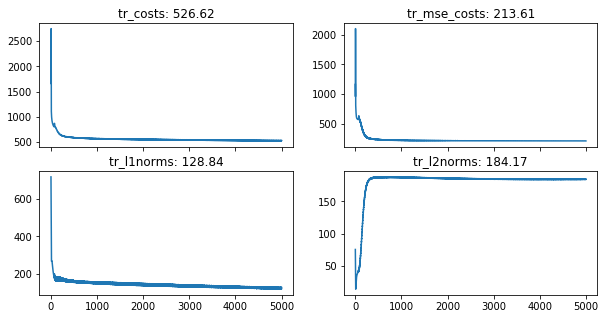

```
training mse: 213.9754, testing mse: 1000.9610
```

```python
# For two-layer with L1/L2-regularization: train and test the model
# define the model
twoLmodel_l1l2 = TF2layer_l1l2(x_dim=x_tr.shape[1], h_dim=5000, alpha_param=1.0, l1param=1.00, l2param=1.00, learning_rate=0.005)
sess = tf.Session(graph=twoLmodel_l1l2.g)
# train the model
tr_costs, tr_mse_costs, tr_l1norms, tr_l2norms = train_model(sess, twoLmodel_l1l2, x_tr, y_tr, n_epochs=5000)

# visualize the cost, mse_cost, l1norm, and l2norm
f, axs = plt.subplots(2, 2, sharex=True, figsize=(10, 5))
axs[0,0].plot(tr_costs)
axs[0,0].set_title('tr_costs: {:.2f}'.format(tr_costs[-1]))
axs[0,1].plot(tr_mse_costs)
axs[0,1].set_title('tr_mse_costs: {:.2f}'.format(tr_mse_costs[-1]))
axs[1,0].plot(tr_l1norms)
axs[1,0].set_title('tr_l1norms: {:.2f}'.format(tr_l1norms[-1]))
axs[1,1].plot(tr_l2norms)
axs[1,1].set_title('tr_l2norms: {:.2f}'.format(tr_l2norms[-1]))
plt.show()

# test the trained model
model = twoLmodel_l1l2
y_tr_pred, mse_err_tr = predict_model(sess, model, x_tr, y_tr)
y_ts_pred, mse_err_ts = predict_model(sess, model, x_ts, y_ts)

print("training mse: {:.4f}, testing mse: {:.4f}".format(mse_err_tr, mse_err_ts))
```

```python
# plot the training data and fitted response for the training data
plt.scatter(x_tr, y_tr, color='red', marker='o', s=50, label='Training data')
plt.scatter(x_ts, y_ts_pred, color='black', marker='s',
        label='Predicted response')
plt.xlabel('x')
plt.ylabel('y')
plt.title("training mse: {:.2f}, testing mse: {:.2f}".format(mse_err_tr, mse_err_ts))
plt.legend()
plt.tight_layout()
plt.show()
```

# One hidden layer neural net model with regularization of weights

## Number of hidden nodes = 5,000

### $\beta = 1.0$ and $\gamma = 1.0$

[figure not shown]

- HPS, Hoyer's sparseness; NZR, non-zero ratio ($\epsilon$ = 0.01)

*code below

```python
# Hoyer's sparseness
def hsp(data_vec):
    data_vec_dim = np.max(data_vec.shape)
    denom = np.sqrt(data_vec_dim) - 1
    numer = np.sqrt(data_vec_dim) - \
        np.sum(np.abs(data_vec))/np.sqrt(np.sum(np.square(data_vec)))
    hsp_val = np.divide(numer, denom)
    return hsp_val

# Non-zero ratio (NZR)
def nzr(data_vec, epsilon=1e-2):
    # since the scale matters, first, normalize, then evaluate the non-zero ratio
    data_vec_norm = np.divide(data_vec, np.sqrt(np.sum(np.square(data_vec))))
    nzr_val = np.sum(np.abs(data_vec_norm) > epsilon) / np.max(data_vec.shape)
    return nzr_val
```

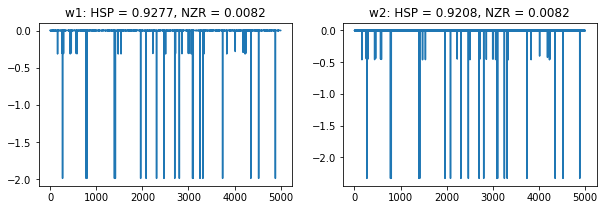

```
Hoyer sparseness of w1: 0.9277, w2: 0.9208
Non-zero ratio (NZR) of w1: 0.0082, w2: 0.0082
```

```python
# plot the weights
w1 = sess.run(model.w1)
w1 = w1.transpose()
w2 = sess.run(model.w2)
f, axs = plt.subplots(1,2, figsize=(10,3))
axs[0].plot(w1)
axs[0].set_title('w1: HSP = {:.4f}, NZR = {:.4f}'.format(hsp(w1), nzr(w1)))
axs[1].plot(w2)
axs[1].set_title('w2: HSP = {:.4f}, NZR = {:.4f}'.format(hsp(w2), nzr(w2)))
plt.show()
#
print('Hoyer sparseness of w1: {:.4f}, w2: {:.4f}'.format(hsp(w1), hsp(w2)))
print('Non-zero ratio (NZR) of w1: {:.4f}, w2: {:.4f}'.format(nzr(w1), nzr(w2)))
```

# One hidden layer neural net model with regularization

## Number of hidden nodes = 5,000

### $\beta = 1.0$ and $\gamma = 0.1$

Model fits better as compared to the one with $\beta = 1.0$ and $\gamma = 1.0$

# One hidden layer neural net model with regularization

## Number of hidden nodes = 5,000

### $\beta = 1.0$ and $\gamma = 0.01$

Model fits better as compared to the one with $\beta = 1.0$ and $\gamma = 0.1$ while retaining the sparse weights.

# One hidden layer neural net model with regularization

## Number of hidden nodes = 5,000

### $\beta = 0.1$ and $\gamma = 0.1$

Model fits even better as compared to the one with $\beta = 1.0$ and $\gamma = 0.1$.  
The model weights became less sparse.

# One hidden layer neural net model with regularization

## Number of hidden nodes = 5,000

### $\beta = 0.1$ and $\gamma = 0.01$

Model fits better as compared to the one with $\beta = 0.1$ and $\gamma = 0.1$.

# One hidden layer neural net model with regularization

## Number of hidden nodes = 5,000

### $\beta = 3.0$ and $\gamma = 0.01$

Model fits less as compared to the one with $\beta = 0.1$ and $\gamma = 0.01$.  
The model weights became much more sparser (i.e., automated feature selection!).

### Ok, now you saw how the L1-norm and L2-norm regularization to weights change the capacity of the networks.

### Particularly, the L1-norm regularization of weights controls the degree of feature selection.

### The problem is that a fixed value of L1-norm parameter keep increasing the level of sparsity:

Also, for a fixed overall learning rate ($\alpha$), the sparseness reached differently depending on the fixed L1-norm parameter.  
For a fixed L1-norm parameter, the sparseness of weights are very different depending on an overall learning rate.

[figure not shown]

## One possible scheme to optimize the model and consequently to select the optimal set of features (particularly for the whole brain MVPA) is to find an optimal level of weight sparsity.

Find an optimal level of weight sparsity using an adaptive L1-norm parameter

$$ \beta (t+1) = \beta (t) - \mu (\rho - nzr(W(t))), $$

where $\beta$ is a L1-norm regularization parameter, $\rho$ is a target weight sparsity level, $W(t)$ is a model weight, $\mu$ is a learning rate adaptively to change the L1-norm regularization parameter, and $t$ is a iteration number of neural network training.

[figure not shown]

Thus, an optimal target sparsity level can be found using a cross-validation with training and validation data  
e.g., grid search among candidate target non-zero ratio values: {0.2, 0.5, 0.8}

# Few more remarks: Sparsity metric

### Non-zero ratio (NZR) is based on L0-norm

$$ NZR = \frac{N(|W| > \epsilon)}{N(W)}, $$

where $N(\cdot)$ is a function to count the number of elements and $\epsilon$ is a threshold to define a zero/non-zero value.

### Hoyer's sparseness (HSP) is based on L1-norm and L2-norm

$$ HSP = \frac{\sqrt{N} - \frac{||W||_1}{||W||_2}}{\sqrt{N} - 1} $$

[figure not shown]

*code below

```python
# Hoyer's sparseness
def hsp(data_vec):
    data_vec_dim = np.max(data_vec.shape)
    denom = np.sqrt(data_vec_dim) - 1
    numer = np.sqrt(data_vec_dim) - \
        np.sum(np.abs(data_vec))/np.sqrt(np.sum(np.square(data_vec)))
    hsp_val = np.divide(numer, denom)
    return hsp_val

#%%
# Non-zero ratio (NZR)
def nzr(data_vec, epsilon=1e-2):
    # since the scale matters, first, normalize, then evaluate the non-zero ratio
    data_vec_norm = np.divide(data_vec, np.sqrt(np.sum(np.square(data_vec))))
    nzr_val = np.sum(np.abs(data_vec_norm) > epsilon) / np.max(data_vec.shape)
    return nzr_val
```

# Few more remarks: Layer-wise vs. Node-wise weight sparsity

### The sparsity of model weights can be defined (a) for each layer and (b) for each node.

Layer-wise weight sparsity

[figure not shown]

Node-wise weight sparsity

[figure not shown]

# In the subsequent hands-on sessions, you will conduct the whole brain MVPA using real fMRI volume data.

Thanks!